# Class 2: outline

Haviland Wright

September 10, 2016

### Textbook

- Lander 2nd edition not available. Reverting to 1st edition.
- Adding [An Introduction to R Version 3.3.1 (2016-06-21)](https://cran.r-project.org/) to the course.
  - Assignment: read first 40 pages  
    ### R and RStudio
- Quick tour of Rstudio. See [RStudio Quick Start Guide](http://tessera.io/docs-r-intro-bootcamp/slides/Quick_Start_Guide_RStudio.pdf) for more detail.
  - See also [RStudio Cheat Sheets](https://www.rstudio.com/resources/cheatsheets/) for an RStudio Reference card.
- Review of project setup for homework and class projects.

### Document authoring in RStudio

What is important about Markdown is that it allows you to author documents that include text and R. A simple way to get started is to simply start a new Markdown file in RStudio. You get a short sample file that gets you started.

There is a reference card for Markdown at [RStudio Cheat Sheets](https://www.rstudio.com/resources/cheatsheets/)

### LaTeX

RStudio also supports Sweave which gives you fuller access to LaTeX. In your setup instructions I suggested that you install Texstudio.

LaTeX is a huge system with broad capability. It is extensively documented. + [The TeX Users Group](https://www.tug.org/) has been in operation since 1980. So, they didn’t start out on the Internet.  
+ The American Mathematical Society has LaTeX information pages on their website [AMS-LaTeX](http://www.ams.org/publications/authors/tex/amslatex)  
+ [LaTeX Wikibook](https://en.wikibooks.org/wiki/LaTeX)  
+ The LaTeX3 project The LaTeX3 project is a long-term research project to develop the next version of the LaTeX typesetting system.  
+ And many more.  
+ If you are new to LaTeX mathematics notation you will find a visual editor handy. There is a good one at [codecogs.com](http://www.codecogs.com/latex/eqneditor.php).  
+ There is a table editor at [LaTeX Table Generator](http://www.tablesgenerator.com/latex_tables#).

```r
x <- 1:10; y <- (1:10)^2
x + y
```

```
##  [1]   2   6  12  20  30  42  56  72  90 110
```

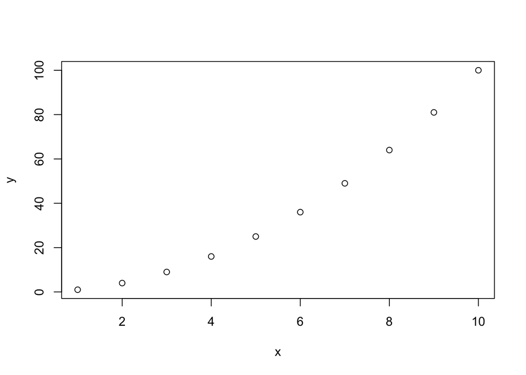

```r
plot(x, y)
```

$\frac{1}{2}$